# Complete calibration procedure for PGA

Here we are showing the complete procedure to calibrate the model and compute regression coefficients for PGA. The output results are manually set based on previously obtained results, because of the computational complexity it takes to rerun the whole procedure. The required libraries are loaded:

```r
library(sf)
library(raster)
library(ggplot2)
library(rgdal)
library(GWmodel)
library(cowplot)
library(geosphere)
library(psych)
library(pracma)
library(reshape2)
library(plot3D)
```

The datasets are loaded:

```r
dataset = readRDS("italian_data_pga.RData")
source("functions.R")
```

The shapefiles are loaded and modified, in order to remove unused regions (Sardinia, Lampedusa, San Marino boundaries):

```r
shape_utm = st_read('confini_ut33.shp')
shape_utm_no_lamp = shape_utm
shape_utm_no_lamp$geometry[[1]][[12]] = NULL

shape_utm_no_sardinia = shape_utm
shape_utm_no_sardinia$geometry[[1]][[3]] = NULL
for (i in 4:10){
  shape_utm_no_sardinia$geometry[[1]][[4]] = NULL
}
for (i in 12:57){
  shape_utm_no_sardinia$geometry[[1]][[5]] = NULL
}
```

Project coordinates of the events to work with UTM33:

```r
latitude_ev = dataset$ev_latitude
longitude_ev = dataset$ev_longitude
long_lat_ev = cbind(longitude_ev, latitude_ev)
utm_ev = project(long_lat_ev, "+proj=utm +zone=33 ellps=WGS84")
utm_ev = as.data.frame(utm_ev)
long_lat_ev = as.data.frame(long_lat_ev)
```

Arrange coordinates of the stations to work with UTM33:

```r
latitude_st = dataset$st_latitude
longitude_st = dataset$st_longitude
long_lat_st = cbind(longitude_st, latitude_st)
utm_st = project(long_lat_st, "+proj=utm +zone=33 ellps=WGS84")
utm_st = as.data.frame(utm_st)
long_lat_st = as.data.frame(long_lat_st)
```

Build spatial points data frame for UTM33 coordinates:

```r
utm_ev_sp = SpatialPointsDataFrame(utm_ev, dataset[,1:6])
utm_st_sp = SpatialPointsDataFrame(utm_st, dataset[,1:6])
```

Transform shapefile into spatial dataframe:

```r
shape_utm_spatial = as_Spatial(shape_utm_no_sardinia)
grid_utm = makegrid(shape_utm_spatial, cellsize = 10000) # cellsize in map units!
grid_utm = SpatialPoints(grid_utm, proj4string = CRS(proj4string(shape_utm_spatial)))
grid_inside_utm = grid_utm[shape_utm_spatial,]
coords_utm = grid_inside_utm@coords
coords_df_utm = as.data.frame(coords_utm)
```

Apply functional on dataset, set parameters and create covariate matrices:

```r
mh = 5.5
mref = 5.324
h = 6.924
attach(dataset)
b1 = (mag-mh)*(mag<=mh)
b2 = (mag-mh)*(mag>mh)
c1 = (mag-mref)*log10(sqrt(JB_complete^2+h^2))
c2 = log10(sqrt(JB_complete^2+h^2))
c3 = sqrt(JB_complete^2+h^2)
f1 = as.numeric(fm_type_code == "SS")
f2 = as.numeric(fm_type_code == "TF")
k = log10(vs30/800)*(vs30<=1500)+log10(1500/800)*(vs30>1500)
y = log10(rotD50_pga)
detach(dataset)

Xc = cbind(b1,b2,f1,f2,c1)
Xe = cbind(c2,c3)
Xs = k
```

The best bandwidth is selected:

```r
bwe_tot = c(10000, 25000, 50000, 75000, 100000)
bws_tot = c(10000, 25000, 50000, 75000, 100000)
n_bwe = length(bwe_tot)
n_bws = length(bws_tot)
bw_table = matrix(0, n_bwe, n_bws)
row.names(bw_table) = bwe_tot
colnames(bw_table) = bws_tot

for (i in 1:n_bwe){
  for (j in 1:n_bws){
    bandwidth = gcv_mei_only_one(i,j,SEC_only_calibration, Xc, Xe, Xs, y, "c", coordinates(utm_ev_sp),
                                 coordinates(utm_st_sp))
    bw_table[i,j] = bandwidth$gcv
  }
}

bw_best = which(bw_table == min(bw_table), arr.ind = T)
bwe = bwe_tot[bw_best[1]]
bws = bws_tot[bw_best[2]]
```

```
[1] 25000
[1] 75000
```

Compare ordinary least squares with completely varying model, in order to justify the introduction o f spatial non-stationarity

```r
#OLS vs completely varying (take R(H1) from here for all stationarity tests)
ols = lm(y ~ Xc + Xe + Xs)
only_intercept = SEC_only_constant_intercept_calibration(Xe, cbind(Xc, Xs), y,
                                                         bwe, bws, coordinates(utm_ev_sp),
                                                         coordinates(utm_st_sp))
n_sample = length(y)
#compute R(H0)
X = cbind(rep(1,n_sample), Xc, Xe, Xs)
I = diag(1,n_sample)
Hols = X%*%(solve(t(X)%*%X))%*%t(X)
RH0 = t(I-Hols)%*%(I-Hols)
epsilon = (I-Hols)%*%y
#compute R(H1)
B = only_intercept$B
Xcc = rep(1,n_sample)
H1 = I - B + B %*% Xcc %*% solve(t(Xcc)%*%t(B)%*%B%*%Xcc) %*% t(Xcc) %*% t(B)%*% B
RH1 = t(I-H1)%*%(I-H1) #use this RH1 for all the following stationarity tests,
                       #it can be saved as "RH1_only_intercept_rotD50pga.RData" to be reloaded later
#compute T
T0 = (t(y) %*% (RH0-RH1) %*% y) / (t(y) %*% RH1 %*% y)
#permutations
n_perm = 1000
t_stat = rep(0,n_perm)
for (i in 1:n_perm){
  eps_star = sample(epsilon)
  y_star = Hols %*% y + eps_star
  t_stat[i] = (t(y_star) %*% (RH0-RH1) %*% y_star) / (t(y_star) %*% RH1 %*% y_star)
}
p_ols = sum(t_stat>as.numeric(T0))/n_perm
```

```
[1] 0
```

Now we check the stationarity of all parameters, using SEC and one at a time:

```r
#check if b1 is stationary (if dependency is not known, it is set as site-dependent)
Xc = b1
Xe = cbind(c2,c3)
Xs = cbind(b2,f1,f2,c1,k)
sec = SEC_only_calibration(Xc, Xe, Xs, y, "c", bwe, bws, coordinates(utm_ev_sp), coordinates(utm_st_sp))
#compute R(H0)
I= diag(1,n_sample)
B = sec$B
Xcc = cbind(rep(1,n_sample), Xc)
H0 = I - B + B %*% Xcc %*% solve(t(Xcc)%*%t(B)%*%B%*%Xcc) %*% t(Xcc) %*% t(B)%*% B
RH0 = t(I-H0)%*%(I-H0)
epsilon= (I-H0)%*%y
#load R(H1)
RH1 = readRDS("RH1_only_intercept_rotD50pga.RData")
#compute T
T0 = (t(y) %*% (RH0-RH1) %*% y) / (t(y) %*% RH1 %*% y)
#permutations
n_perm = 1000
t_stat = rep(0,n_perm)
for (i in 1:n_perm){
  eps_star = sample(epsilon)
  y_star = H0 %*% y + eps_star
  t_stat[i] = (t(y_star) %*% (RH0-RH1) %*% y_star) / (t(y_star) %*% RH1 %*% y_star)
}
p_b1 = sum(t_stat>as.numeric(T0))/n_perm
```

```
[1] 0.988
```

```r
#check if b2 is stationary
Xc = b2
Xe = cbind(c2,c3)
Xs = cbind(b1,f1,f2,c1,k)
sec = SEC_only_calibration(Xc, Xe, Xs, y, "c", bwe, bws, coordinates(utm_ev_sp), coordinates(utm_st_sp))
#compute R(H0)
I= diag(1,n_sample)
B = sec$B
Xcc = cbind(rep(1,n_sample), Xc)
H0 = I - B + B %*% Xcc %*% solve(t(Xcc)%*%t(B)%*%B%*%Xcc) %*% t(Xcc) %*% t(B)%*% B
RH0 = t(I-H0)%*%(I-H0)
epsilon= (I-H0)%*%y
#load R(H1)
RH1 = readRDS("RH1_only_intercept_rotD50pga.RData")
#compute T
T0 = (t(y) %*% (RH0-RH1) %*% y) / (t(y) %*% RH1 %*% y)
#permutations
n_perm = 1000
t_stat = rep(0,n_perm)
for (i in 1:n_perm){
  eps_star = sample(epsilon)
  y_star = H0 %*% y + eps_star
  t_stat[i] = (t(y_star) %*% (RH0-RH1) %*% y_star) / (t(y_star) %*% RH1 %*% y_star)
}
p_b2 = sum(t_stat>as.numeric(T0))/n_perm
```

```
[1] 0.116
```

```r
#check if f1 is stationary
Xc = f1
Xe = cbind(c2,c3)
Xs = cbind(b1,b2,f2,c1,k)
sec = SEC_only_calibration(Xc, Xe, Xs, y, "c", bwe, bws, coordinates(utm_ev_sp), coordinates(utm_st_sp))
#compute R(H0)
I= diag(1,n_sample)
B = sec$B
Xcc = cbind(rep(1,n_sample), Xc)
H0 = I - B + B %*% Xcc %*% solve(t(Xcc)%*%t(B)%*%B%*%Xcc) %*% t(Xcc) %*% t(B)%*% B
RH0 = t(I-H0)%*%(I-H0)
epsilon= (I-H0)%*%y
#load R(H1)
RH1 = readRDS("RH1_only_intercept_rotD50pga.RData")
#compute T
T0 = (t(y) %*% (RH0-RH1) %*% y) / (t(y) %*% RH1 %*% y)
#permutations
n_perm = 1000
t_stat = rep(0,n_perm)
for (i in 1:n_perm){
  eps_star = sample(epsilon)
  y_star = H0 %*% y + eps_star
  t_stat[i] = (t(y_star) %*% (RH0-RH1) %*% y_star) / (t(y_star) %*% RH1 %*% y_star)
}
p_f1 = sum(t_stat>as.numeric(T0))/n_perm
```

```
[1] 0.972
```

```r
#check if f2 is stationary
Xc = f2
Xe = cbind(c2,c3)
Xs = cbind(b1,b2,f1,c1,k)
sec = SEC_only_calibration(Xc, Xe, Xs, y, "c", bwe, bws, coordinates(utm_ev_sp), coordinates(utm_st_sp))

#compute R(H0)
I= diag(1,n_sample)
B = sec$B
Xcc = cbind(rep(1,n_sample), Xc)
H0 = I - B + B %*% Xcc %*% solve(t(Xcc)%*%t(B)%*%B%*%Xcc) %*% t(Xcc) %*% t(B)%*% B
RH0 = t(I-H0)%*%(I-H0)
epsilon= (I-H0)%*%y
#load R(H1)
RH1 = readRDS("RH1_only_intercept_rotD50pga.RData")
#compute T
T0 = (t(y) %*% (RH0-RH1) %*% y) / (t(y) %*% RH1 %*% y)
#permutations
n_perm = 1000
t_stat = rep(0,n_perm)
for (i in 1:n_perm){
  eps_star = sample(epsilon)
  y_star = H0 %*% y + eps_star
  t_stat[i] = (t(y_star) %*% (RH0-RH1) %*% y_star) / (t(y_star) %*% RH1 %*% y_star)
}
p_f2 = sum(t_stat>as.numeric(T0))/n_perm
```

```
[1] 0.033
```

```r
#check if c1 is stationary
Xc = c1
Xe = cbind(c2,c3)
Xs = cbind(b1,b2,f1,f2,k)
sec = SEC_only_calibration(Xc, Xe, Xs, y, "c", bwe, bws, coordinates(utm_ev_sp), coordinates(utm_st_sp))
#compute R(H0)
I= diag(1,n_sample)
B = sec$B
Xcc = cbind(rep(1,n_sample), Xc)
H0 = I - B + B %*% Xcc %*% solve(t(Xcc)%*%t(B)%*%B%*%Xcc) %*% t(Xcc) %*% t(B)%*% B
RH0 = t(I-H0)%*%(I-H0)
epsilon= (I-H0)%*%y
#load R(H1)
RH1 = readRDS("RH1_only_intercept_rotD50pga.RData")
#compute T
T0 = (t(y) %*% (RH0-RH1) %*% y) / (t(y) %*% RH1 %*% y)
#permutations
n_perm = 1000
t_stat = rep(0,n_perm)
for (i in 1:n_perm){
  eps_star = sample(epsilon)
  y_star = H0 %*% y + eps_star
  t_stat[i] = (t(y_star) %*% (RH0-RH1) %*% y_star) / (t(y_star) %*% RH1 %*% y_star)
}
p_c1 = sum(t_stat>as.numeric(T0))/n_perm
```

```
[1] 0.156
```

```r
#check if c2 is stationary
Xc = c2
Xe = c3
Xs = cbind(b1,b2,f1,f2,c1,k)
sec = SEC_only_calibration(Xc, Xe, Xs, y, "c", bwe, bws, coordinates(utm_ev_sp), coordinates(utm_st_sp))
#compute R(H0)
I= diag(1,n_sample)
B = sec$B
Xcc = cbind(rep(1,n_sample), Xc)
H0 = I - B + B %*% Xcc %*% solve(t(Xcc)%*%t(B)%*%B%*%Xcc) %*% t(Xcc) %*% t(B)%*% B
RH0 = t(I-H0)%*%(I-H0)
epsilon= (I-H0)%*%y
#load R(H1)
RH1 = readRDS("RH1_only_intercept_rotD50pga.RData")
#compute T
T0 = (t(y) %*% (RH0-RH1) %*% y) / (t(y) %*% RH1 %*% y)

#permutations
n_perm = 1000
t_stat = rep(0,n_perm)
for (i in 1:n_perm){
  eps_star = sample(epsilon)
  y_star = H0 %*% y + eps_star
  t_stat[i] = (t(y_star) %*% (RH0-RH1) %*% y_star) / (t(y_star) %*% RH1 %*% y_star)
}
p_c2 = sum(t_stat>as.numeric(T0))/n_perm
```

```
[1] 0.047
```

```r
#check if c3 is stationary
Xc = c3
Xe = c2
Xs = cbind(b1,b2,f1,f2,c1,k)
sec = SEC_only_calibration(Xc, Xe, Xs, y, "c", bwe, bws, coordinates(utm_ev_sp), coordinates(utm_st_sp))
#compute R(H0)
I= diag(1,n_sample)
B = sec$B
Xcc = cbind(rep(1,n_sample), Xc)
H0 = I - B + B %*% Xcc %*% solve(t(Xcc)%*%t(B)%*%B%*%Xcc) %*% t(Xcc) %*% t(B)%*% B
RH0 = t(I-H0)%*%(I-H0)
epsilon= (I-H0)%*%y
#load R(H1)
RH1 = readRDS("RH1_only_intercept_rotD50pga.RData")
#compute T
T0 = (t(y) %*% (RH0-RH1) %*% y) / (t(y) %*% RH1 %*% y)
#permutations
n_perm = 1000
t_stat = rep(0,n_perm)
for (i in 1:n_perm){
  eps_star = sample(epsilon)
  y_star = H0 %*% y + eps_star
  t_stat[i] = (t(y_star) %*% (RH0-RH1) %*% y_star) / (t(y_star) %*% RH1 %*% y_star)
}
p_c3 = sum(t_stat>as.numeric(T0))/n_perm
```

```
[1] 0.012
```

```r
#check if k is stationary
Xc = k
Xe = cbind(c2,c3)
Xs = cbind(b1,b2,f1,f2,c1)
sec = SEC_only_calibration(Xc, Xe, Xs, y, "c", bwe, bws, coordinates(utm_ev_sp), coordinates(utm_st_sp))
#compute R(H0)
I= diag(1,n_sample)
B = sec$B
Xcc = cbind(rep(1,n_sample), Xc)
H0 = I - B + B %*% Xcc %*% solve(t(Xcc)%*%t(B)%*%B%*%Xcc) %*% t(Xcc) %*% t(B)%*% B
RH0 = t(I-H0)%*%(I-H0)
epsilon= (I-H0)%*%y
#load R(H1)
RH1 = readRDS("RH1_only_intercept_rotD50pga.RData")
#compute T
T0 = (t(y) %*% (RH0-RH1) %*% y) / (t(y) %*% RH1 %*% y)
#permutations
n_perm = 1000
t_stat = rep(0,n_perm)
for (i in 1:n_perm){
  eps_star = sample(epsilon)
  y_star = H0 %*% y + eps_star
  t_stat[i] = (t(y_star) %*% (RH0-RH1) %*% y_star) / (t(y_star) %*% RH1 %*% y_star)
}
p_k = sum(t_stat>as.numeric(T0))/n_perm
```

```
[1] 0.087
```

The previous results and our previous knowledge from literature are verified jointly:

```r
#check jointly if they are stationary
Xc = cbind(b1,b2,f1,f2,c1)
Xe = cbind(c2,c3)
Xs = k
ols = lm(y ~ Xc + Xe + Xs)
sec = SEC_only_calibration(Xc, Xe, Xs, y, "c", bwe, bws, coordinates(utm_ev_sp), coordinates(utm_st_sp))
#compute R(H0)
X = cbind(rep(1,n_sample), Xc, Xe, Xs)
I = diag(1,n_sample)
Hols = X%*%(solve(t(X)%*%X))%*%t(X)
RH0 = t(I-Hols)%*%(I-Hols)
epsilon = (I-Hols)%*%y
#compute R(H1)
I= diag(1,n_sample)
B = sec$B
Xcc = cbind(rep(1,n_sample), Xc)
H0 = I - B + B %*% Xcc %*% solve(t(Xcc)%*%t(B)%*%B%*%Xcc) %*% t(Xcc) %*% t(B)%*% B
RH1 = t(I-H0)%*%(I-H0) #it can be saved as "RH1_stationary_rotD50pga.RData" to be reloaded for the following tests
#compute T
T0 = (t(y) %*% (RH0-RH1) %*% y) / (t(y) %*% RH1 %*% y)
#permutations
n_perm = 1000
t_stat = rep(0,n_perm)
for (i in 1:n_perm){
  eps_star = sample(epsilon)
  y_star = H0 %*% y + eps_star
  t_stat[i] = (t(y_star) %*% (RH0-RH1) %*% y_star) / (t(y_star) %*% RH1 %*% y_star)
}
p_cumulative_stationary = sum(t_stat>as.numeric(T0))/n_perm
```

```
[1] 0.078
```

Now we have to check if the stationary coefficients are significant or if they can be considered as 0, at first one at a time. They are not checked jointly since all of them are kept, in order to be able to have a direct comparison with ITA18.

```r
#check if the intercept is null (as R(H1) take R(H1) from previous point)
Xc = cbind(b1,b2,f1,f2,c1)
Xe = cbind(c2,c3)
Xs = k
sec_null = SEC_no_intercept_calibration(Xc, Xe, Xs, y, bwe, bws, coordinates(utm_ev_sp), coordinates(utm_st_sp))
sec = SEC_only_calibration(Xc, Xe, Xs, y, "c", bwe, bws, coordinates(utm_ev_sp), coordinates(utm_st_sp))
#compute R(H0)
I= diag(1,n_sample)
B = sec_null$B
Xcc = Xc
H0 = I - B + B %*% Xcc %*% solve(t(Xcc)%*%t(B)%*%B%*%Xcc) %*% t(Xcc) %*% t(B)%*% B
RH0 = t(I-H0)%*%(I-H0)
epsilon= (I-H0)%*%y
#load R(H1)
RH1 = readRDS("RH1_stationary_rotD50pga.RData")
#compute T
T0 = (t(y) %*% (RH0-RH1) %*% y) / (t(y) %*% RH1 %*% y)
#permutations
n_perm = 1000
t_stat = rep(0,n_perm)
for (i in 1:n_perm){
  eps_star = sample(epsilon)
  y_star = H0 %*% y + eps_star
  t_stat[i] = (t(y_star) %*% (RH0-RH1) %*% y_star) / (t(y_star) %*% RH1 %*% y_star)
}
p_a_null = sum(t_stat>as.numeric(T0))/n_perm
```

```
[1] 0
```

```r
#check if b1 is null
Xc = cbind(b2,f1,f2,c1)
Xe = cbind(c2,c3)
Xs = k
sec_null = SEC_only_calibration(Xc, Xe, Xs, y, "c", bwe, bws, coordinates(utm_ev_sp), coordinates(utm_st_sp))
#compute R(H0)
I= diag(1,n_sample)
B = sec_null$B
Xcc = cbind(rep(1,n_sample), Xc)
H0 = I - B + B %*% Xcc %*% solve(t(Xcc)%*%t(B)%*%B%*%Xcc) %*% t(Xcc) %*% t(B)%*% B
RH0 = t(I-H0)%*%(I-H0)
epsilon= (I-H0)%*%y
#load R(H1)
RH1 = readRDS("RH1_stationary_rotD50pga.RData")
#compute T
T0 = (t(y) %*% (RH0-RH1) %*% y) / (t(y) %*% RH1 %*% y)
#permutations
n_perm = 1000
t_stat = rep(0,n_perm)
for (i in 1:n_perm){
  eps_star = sample(epsilon)
  y_star = H0 %*% y + eps_star
  t_stat[i] = (t(y_star) %*% (RH0-RH1) %*% y_star) / (t(y_star) %*% RH1 %*% y_star)
}
p_b1_null = sum(t_stat>as.numeric(T0))/n_perm
```

```
[1] 0
```

```r
#check if b2 is null
Xc = cbind(b1,f1,f2,c1)
Xe = cbind(c2,c3)
Xs = k
sec_null = SEC_only_calibration(Xc, Xe, Xs, y, "c", bwe, bws, coordinates(utm_ev_sp), coordinates(utm_st_sp))
#compute R(H0)
I= diag(1,n_sample)
B = sec_null$B
Xcc = cbind(rep(1,n_sample), Xc)
H0 = I - B + B %*% Xcc %*% solve(t(Xcc)%*%t(B)%*%B%*%Xcc) %*% t(Xcc) %*% t(B)%*% B
RH0 = t(I-H0)%*%(I-H0)
epsilon= (I-H0)%*%y
#load R(H1)
RH1 = readRDS("RH1_stationary_rotD50pga.RData")
#compute T
T0 = (t(y) %*% (RH0-RH1) %*% y) / (t(y) %*% RH1 %*% y)
#permutations
n_perm = 1000
t_stat = rep(0,n_perm)
for (i in 1:n_perm){
  eps_star = sample(epsilon)
  y_star = H0 %*% y + eps_star
  t_stat[i] = (t(y_star) %*% (RH0-RH1) %*% y_star) / (t(y_star) %*% RH1 %*% y_star)
}
p_b2_null = sum(t_stat>as.numeric(T0))/n_perm
```

```
[1] 0.151
```

```r
#check if f1 is null
Xc = cbind(b1,b2,f2,c1)
Xe = cbind(c2,c3)
Xs = k
sec_null = SEC_only_calibration(Xc, Xe, Xs, y, "c", bwe, bws, coordinates(utm_ev_sp), coordinates(utm_st_sp))
#compute R(H0)
I= diag(1,n_sample)
B = sec_null$B
Xcc = cbind(rep(1,n_sample), Xc)
H0 = I - B + B %*% Xcc %*% solve(t(Xcc)%*%t(B)%*%B%*%Xcc) %*% t(Xcc) %*% t(B)%*% B
RH0 = t(I-H0)%*%(I-H0)
epsilon= (I-H0)%*%y
#load R(H1)
RH1 = readRDS("RH1_stationary_rotD50pga.RData")
#compute T
T0 = (t(y) %*% (RH0-RH1) %*% y) / (t(y) %*% RH1 %*% y)
#permutations
n_perm = 1000
t_stat = rep(0,n_perm)
for (i in 1:n_perm){
  eps_star = sample(epsilon)
  y_star = H0 %*% y + eps_star
  t_stat[i] = (t(y_star) %*% (RH0-RH1) %*% y_star) / (t(y_star) %*% RH1 %*% y_star)
}
p_f1_null = sum(t_stat>as.numeric(T0))/n_perm
```

```
[1] 0.031
```

```r
#check if f2 is null
Xc = cbind(b1,b2,f1,c1)
Xe = cbind(c2,c3)
Xs = k
sec_null = SEC_only_calibration(Xc, Xe, Xs, y, "c", bwe, bws, coordinates(utm_ev_sp), coordinates(utm_st_sp))
#compute R(H0)
I= diag(1,n_sample)
B = sec_null$B
Xcc = cbind(rep(1,n_sample), Xc)
H0 = I - B + B %*% Xcc %*% solve(t(Xcc)%*%t(B)%*%B%*%Xcc) %*% t(Xcc) %*% t(B)%*% B
RH0 = t(I-H0)%*%(I-H0)
epsilon= (I-H0)%*%y
#load R(H1)
RH1 = readRDS("RH1_stationary_rotD50pga.RData")
#compute T
T0 = (t(y) %*% (RH0-RH1) %*% y) / (t(y) %*% RH1 %*% y)
#permutations
n_perm = 1000
t_stat = rep(0,n_perm)
for (i in 1:n_perm){
  eps_star = sample(epsilon)
  y_star = H0 %*% y + eps_star
  t_stat[i] = (t(y_star) %*% (RH0-RH1) %*% y_star) / (t(y_star) %*% RH1 %*% y_star)
}
p_f2_null = sum(t_stat>as.numeric(T0))/n_perm
```

```
[1] 0.117
```

```r
#check if c1 is null
Xc = cbind(b1,b2,f1,f2)
Xe = cbind(c2,c3)
Xs = k
sec_null = SEC_only_calibration(Xc, Xe, Xs, y, "c", bwe, bws, coordinates(utm_ev_sp), coordinates(utm_st_sp))
#compute R(H0)
I= diag(1,n_sample)
B = sec_null$B
Xcc = cbind(rep(1,n_sample), Xc)
H0 = I - B + B %*% Xcc %*% solve(t(Xcc)%*%t(B)%*%B%*%Xcc) %*% t(Xcc) %*% t(B)%*% B
RH0 = t(I-H0)%*%(I-H0)
epsilon= (I-H0)%*%y
#load R(H1)
RH1 = readRDS("RH1_stationary_rotD50pga.RData")
#compute T
T0 = (t(y) %*% (RH0-RH1) %*% y) / (t(y) %*% RH1 %*% y)
#permutations
n_perm = 1000
t_stat = rep(0,n_perm)
for (i in 1:n_perm){
  eps_star = sample(epsilon)
  y_star = H0 %*% y + eps_star
  t_stat[i] = (t(y_star) %*% (RH0-RH1) %*% y_star) / (t(y_star) %*% RH1 %*% y_star)
}
p_c1_null = sum(t_stat>as.numeric(T0))/n_perm
```

```
[1] 0
```

```r
Xc = cbind(b1,b2,f1,f2,c1)
Xe = cbind(c2,c3)
Xs = k
gcv_mei_only_one(bwe,bws,ESC_only_calibration, Xc, Xe, Xs, y, "c", coordinates(utm_ev_sp),
                 coordinates(utm_st_sp)) #compare this GCV with the one obtained in bandwidth selection
```

The next step is to compute $R^2_{adj}$

```r
Xc = cbind(b1,b2,f1,f2,c1)
Xe = cbind(c2,c3)
Xs = k
sec = SEC_only_calibration(Xc, Xe, Xs, y, "c", bwe, bws, coordinates(utm_ev_sp), coordinates(utm_st_sp))
n_sample = length(y)
I= diag(1,n_sample)
B = sec$B
Xcc = cbind(rep(1,n_sample), Xc)
H = I - B + B %*% Xcc %*% solve(t(Xcc)%*%t(B)%*%B%*%Xcc) %*% t(Xcc) %*% t(B)%*% B #this can be saved as                                                                                      #"H_hat_pga.RData"
epsilon= (I-H)%*%y
delta1 = n_sample-2*tr(H)+tr(t(H)%*%H) #this can be saved as "delta1_pga.RData"
delta2 = tr((t(I-H)%*%(I-H)) %*% (t(I-H)%*%(I-H))) #this can be saved as "delta1_pga.RData"
rss = sum(epsilon^2)
sigma2hat = rss/delta1
tss = sum((H%*%y-mean(y))^2)
sqrt(sigma2hat)
R2 = 1-rss/tss
R2adj = 1-(1-R2)*(n_sample-1)/delta1
```

```
[1] 0.878
```

Now we can compute all the regression coefficients:

```r
result = SEC_grid_creation(Xc, Xe, Xs, y,"c", bwe, bws, coordinates(utm_ev_sp),
                           coordinates(utm_st_sp), coords_utm, sec)
beta_const = result$beta_c

beta_k = t(result$beta_s)
beta_k_coord = cbind(coords_utm, beta_k)
beta_k_coord = as.data.frame(beta_k_coord)

beta_c2 = result$beta_e[1,]
beta_c2_coord = cbind(coords_utm, beta_c2)
beta_c2_coord = as.data.frame(beta_c2_coord)

beta_c3 = result$beta_e[2,]
beta_c3_coord = cbind(coords_utm, beta_c3)
beta_c3_coord = as.data.frame(beta_c3_coord)
```

```
          [,1]
    3.55020372
b1  0.23539033
b2 -0.05134211
f1  0.05103326
f2  0.03935460
c1  0.26536756
```

The non-stationary regression coefficients can be plotted:

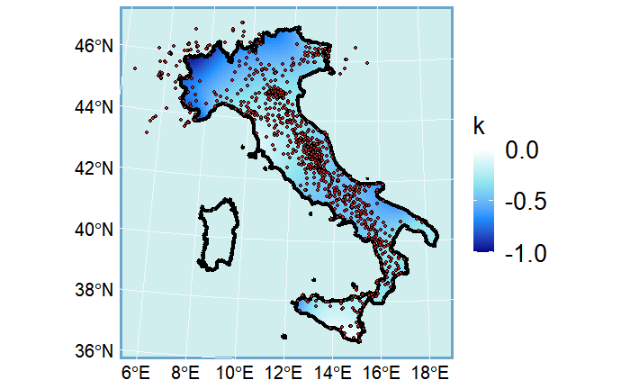

```r
ggplot() +
  geom_tile(beta_k_coord, mapping = aes(x=x1, y=x2, fill=beta_k))+
  scale_fill_gradientn(colours = c("darkblue", "dodgerblue1", "cadetblue2", "white"), name = "k"
                       ,limits = c(-1,0), breaks = c(-1, -0.5,0)
  )+
  geom_sf(data = shape_utm_no_lamp, size = 1.6, color = "black", fill = NA )+
  geom_point(data = utm_st, aes(x=longitude_st, y=latitude_st), fill= 'firebrick3',
             size = 1, shape = 21, stroke = 0.7)+
  theme(axis.text=element_text(size=15, colour = "black"),
        axis.title=element_blank(),
        legend.text=element_text(size=20, colour = "black"),
        plot.title = element_blank(),
        axis.ticks=element_blank(),
        legend.title = element_text(size=20, colour = "black"),
        panel.background = element_rect(fill = "lightcyan2", colour = "skyblue3",
                                        size = 2, linetype = "solid"),
        panel.grid = element_line(size = 0.25, linetype = 'solid',
                                  colour = "aliceblue")
  )
```

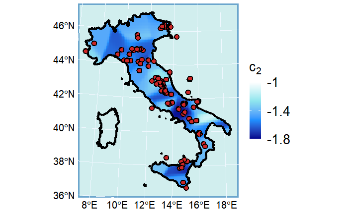

```r
ggplot() +
  geom_tile(beta_c2_coord, mapping = aes(x=x1, y=x2, fill=beta_c2))+
  #coord_sf()+
  scale_fill_gradientn(colours = c("darkblue", "dodgerblue1", "cadetblue2", "white")
                       , name = expression(paste(c[2]))
                       ,limits = c(-1.8, -1), breaks = c(-1.8, -1.4, -1),
                       labels = c(-1.8, -1.4, -1))+
  geom_sf(data = shape_utm_no_lamp, size = 1.6, color = "black", fill = NA)+
  geom_point(data = utm_ev, aes(x=longitude_ev, y=latitude_ev), fill= 'firebrick3',
             size = 3, shape = 21, stroke = 1.5)+
  theme(axis.text=element_text(size=15, colour = "black"),
        axis.title=element_blank(),
        legend.text=element_text(size=20, colour = "black"),
        plot.title = element_blank(),
        axis.ticks=element_blank(),
        legend.title = element_text(size=20, colour = "black"),
        panel.background = element_rect(fill = "lightcyan2", colour = "skyblue3",
                                        size = 2, linetype = "solid"),
        panel.grid = element_line(size = 0.25, linetype = 'solid',
                                  colour = "aliceblue")
  )
```

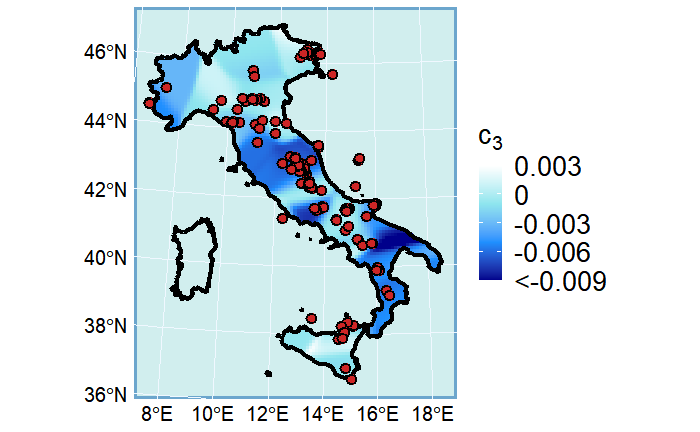

```r
beta_c3_bis = beta_c3
beta_c3_bis[beta_c3_bis<(-0.009)]=-0.009
beta_c3_coord = cbind(coords_utm, beta_c3)
beta_c3_coord = as.data.frame(beta_c3_coord)
beta_c3_bis_coord = cbind(coords_utm, beta_c3_bis)
beta_c3_bis_coord = as.data.frame(beta_c3_bis_coord)

ggplot() +
  geom_tile(beta_c3_bis_coord, mapping = aes(x=x1, y=x2, fill=beta_c3_bis))+
  scale_fill_gradientn(colours = c("darkblue", "dodgerblue1", "cadetblue2", "white")
                       , name = expression(paste(c[3]))
                       ,limits = c(-0.009, 0.003), breaks = c(-0.009, -0.006, -0.003, 0, 0.003),
                       labels = c("<-0.009", -0.006, -0.003, 0, 0.003))+
  geom_sf(data = shape_utm_no_lamp, size = 1.6, color = "black", fill = NA)+
  geom_point(data = utm_ev, aes(x=longitude_ev, y=latitude_ev), fill= 'firebrick3',
             size = 3, shape = 21, stroke = 1.5)+
  theme(axis.text=element_text(size=15, colour = "black"),
        axis.title=element_blank(),
        legend.text=element_text(size=20, colour = "black"),
        plot.title = element_blank(),
        axis.ticks=element_blank(),
        legend.title = element_text(size=20, colour = "black"),
        panel.background = element_rect(fill = "lightcyan2", colour = "skyblue3",
                                        size = 2, linetype = "solid"),
        panel.grid = element_line(size = 0.25, linetype = 'solid',
                                  colour = "aliceblue")
  )
```

The calibration procedure is complete, with the obtained results and using the other functions contained in the functions file we can predict, evaluate and use the obtained GMPE.